# "On my honor, as a student, I have neither given nor received unauthorized aid on this academic work."

[figure not shown]

```python
from IPython.display import Image
Image("shawshank-redemption.jpg")
```

# 1. Business Understanding

# - 1. Project Goals

## The goal of this project is determine what variables effect the success of a movie. We will do this through analyzing data associated with past movies and comparing those variables to the score the movie received on IMDB. The hope of this analysis is for us to gain insight into what people like in movies with the hope of being able to create movies that are more successful in the future.

# - 2. If you’re hired as a data/business analyst to predict how well a movie will perform in theaters, what kind of data would you collect?

## As a business analyst I would want to have access to key variables related to movies such as the duration, actors, genres, language, ratings, budgets, plots, themes.

# - 3. What variables are highly correlated to imdb score? In this project, you will use imdb_score to measure a movie’s success.

# 2. Data Understanding

```python
import pandas as pd
import numpy as np
import matplotlib.pyplot as plt
import seaborn as sns

%matplotlib inline
```

```python
df = pd.read_csv("movie_metadata.csv")
```

```python
df.head()
```

|  | color | director_name | num_critic_for_reviews | duration | director_facebook_likes | actor_3_facebook_likes | actor_2_name | actor_1_facebook_likes | gross | genres | ... | num_user_for_reviews | language | country | content_rating | budget | title_year | actor_2_facebook_likes | imdb_score | aspect_ratio | movie_facebook_likes |
| --- | --- | --- | --- | --- | --- | --- | --- | --- | --- | --- | --- | --- | --- | --- | --- | --- | --- | --- | --- | --- | --- |
| 0 | Color | James Cameron | 723.0 | 178.0 | 0.0 | 855.0 | Joel David Moore | 1000.0 | 760505847.0 | Action\|Adventure\|Fantasy\|Sci-Fi | ... | 3054.0 | English | USA | PG-13 | 237000000.0 | 2009.0 | 936.0 | 7.9 | 1.78 | 33000 |
| 1 | Color | Gore Verbinski | 302.0 | 169.0 | 563.0 | 1000.0 | Orlando Bloom | 40000.0 | 309404152.0 | Action\|Adventure\|Fantasy | ... | 1238.0 | English | USA | PG-13 | 300000000.0 | 2007.0 | 5000.0 | 7.1 | 2.35 | 0 |
| 2 | Color | Sam Mendes | 602.0 | 148.0 | 0.0 | 161.0 | Rory Kinnear | 11000.0 | 200074175.0 | Action\|Adventure\|Thriller | ... | 994.0 | English | UK | PG-13 | 245000000.0 | 2015.0 | 393.0 | 6.8 | 2.35 | 85000 |
| 3 | Color | Christopher Nolan | 813.0 | 164.0 | 22000.0 | 23000.0 | Christian Bale | 27000.0 | 448130642.0 | Action\|Thriller | ... | 2701.0 | English | USA | PG-13 | 250000000.0 | 2012.0 | 23000.0 | 8.5 | 2.35 | 164000 |
| 4 | NaN | Doug Walker | NaN | NaN | 131.0 | NaN | Rob Walker | 131.0 | NaN | Documentary | ... | NaN | NaN | NaN | NaN | NaN | NaN | 12.0 | 7.1 | NaN | 0 |

5 rows × 28 columns

```python
df.info()
```

```
<class 'pandas.core.frame.DataFrame'>
RangeIndex: 5043 entries, 0 to 5042
Data columns (total 28 columns):
color                        5024 non-null object
director_name                4939 non-null object
num_critic_for_reviews       4993 non-null float64
duration                     5028 non-null float64
director_facebook_likes      4939 non-null float64
actor_3_facebook_likes       5020 non-null float64
actor_2_name                 5030 non-null object
actor_1_facebook_likes       5036 non-null float64
gross                        4159 non-null float64
genres                       5043 non-null object
actor_1_name                 5036 non-null object
movie_title                  5043 non-null object
num_voted_users              5043 non-null int64
cast_total_facebook_likes    5043 non-null int64
actor_3_name                 5020 non-null object
facenumber_in_poster         5030 non-null float64
plot_keywords                4890 non-null object
movie_imdb_link              5043 non-null object
num_user_for_reviews         5022 non-null float64
language                     5031 non-null object
country                      5038 non-null object
content_rating               4740 non-null object
budget                       4551 non-null float64
title_year                   4935 non-null float64
actor_2_facebook_likes       5030 non-null float64
imdb_score                   5043 non-null float64
aspect_ratio                 4714 non-null float64
movie_facebook_likes         5043 non-null int64
dtypes: float64(13), int64(3), object(12)
memory usage: 1.1+ MB
```

```python
df.isnull().sum()
```

```
color                         19
director_name                104
num_critic_for_reviews        50
duration                      15
director_facebook_likes      104
actor_3_facebook_likes        23
actor_2_name                  13
actor_1_facebook_likes         7
gross                        884
genres                         0
actor_1_name                   7
movie_title                    0
num_voted_users                0
cast_total_facebook_likes      0
actor_3_name                  23
facenumber_in_poster          13
plot_keywords                153
movie_imdb_link                0
num_user_for_reviews          21
language                      12
country                        5
content_rating               303
budget                       492
title_year                   108
actor_2_facebook_likes        13
imdb_score                     0
aspect_ratio                 329
movie_facebook_likes           0
dtype: int64
```

# 3. Data Preperation

```python
df.fillna({'gross': df['gross'].mean()})
df.fillna({'budget': df['budget'].mean()})
df.fillna({'director_facebook_likes': df['director_facebook_likes'].mean()})
df.fillna({'duration': df['duration'].mean()})
```

[output not shown]

5043 rows × 28 columns

```python
df = df.dropna()
```

```python
##dummy variables
color_dummies = pd.get_dummies(df['color'], prefix = 'color')
df = df.join(color_dummies)
content_dummies = pd.get_dummies(df['content_rating'], prefix = 'rating_')
df = df.join(content_dummies)

df= df.drop(['color', 'content_rating'], axis = 1)
```

```python
df = df.drop(['gross', 'cast_total_facebook_likes', 'num_critic_for_reviews','num_voted_users','movie_facebook_likes'], axis = 1)
```

```python
df.info()
```

```
<class 'pandas.core.frame.DataFrame'>
Int64Index: 3756 entries, 0 to 5042
Data columns (total 35 columns):
director_name              3756 non-null object
duration                   3756 non-null float64
director_facebook_likes    3756 non-null float64
actor_3_facebook_likes     3756 non-null float64
actor_2_name               3756 non-null object
actor_1_facebook_likes     3756 non-null float64
genres                     3756 non-null object
actor_1_name               3756 non-null object
movie_title                3756 non-null object
actor_3_name               3756 non-null object
facenumber_in_poster       3756 non-null float64
plot_keywords              3756 non-null object
movie_imdb_link            3756 non-null object
num_user_for_reviews       3756 non-null float64
language                   3756 non-null object
country                    3756 non-null object
budget                     3756 non-null float64
title_year                 3756 non-null float64
actor_2_facebook_likes     3756 non-null float64
imdb_score                 3756 non-null float64
aspect_ratio               3756 non-null float64
color_ Black and White     3756 non-null uint8
color_Color                3756 non-null uint8
rating__Approved           3756 non-null uint8
rating__G                  3756 non-null uint8
rating__GP                 3756 non-null uint8
rating__M                  3756 non-null uint8
rating__NC-17              3756 non-null uint8
rating__Not Rated          3756 non-null uint8
rating__PG                 3756 non-null uint8
rating__PG-13              3756 non-null uint8
rating__Passed             3756 non-null uint8
rating__R                  3756 non-null uint8
rating__Unrated            3756 non-null uint8
rating__X                  3756 non-null uint8
dtypes: float64(11), object(10), uint8(14)
memory usage: 856.9+ KB
```

```python
df.isnull().sum()
```

```
director_name              0
duration                   0
director_facebook_likes    0
actor_3_facebook_likes     0
actor_2_name               0
actor_1_facebook_likes     0
genres                     0
actor_1_name               0
movie_title                0
actor_3_name               0
facenumber_in_poster       0
plot_keywords              0
movie_imdb_link            0
num_user_for_reviews       0
language                   0
country                    0
budget                     0
title_year                 0
actor_2_facebook_likes     0
imdb_score                 0
aspect_ratio               0
color_ Black and White     0
color_Color                0
rating__Approved           0
rating__G                  0
rating__GP                 0
rating__M                  0
rating__NC-17              0
rating__Not Rated          0
rating__PG                 0
rating__PG-13              0
rating__Passed             0
rating__R                  0
rating__Unrated            0
rating__X                  0
dtype: int64
```

```python
df.describe()
```

|  | duration | director_facebook_likes | actor_3_facebook_likes | actor_1_facebook_likes | facenumber_in_poster | num_user_for_reviews | budget | title_year | actor_2_facebook_likes | imdb_score | ... | rating__GP | rating__M | rating__NC-17 | rating__Not Rated | rating__PG | rating__PG-13 | rating__Passed | rating__R | rating__Unrated | rating__X |
| --- | --- | --- | --- | --- | --- | --- | --- | --- | --- | --- | --- | --- | --- | --- | --- | --- | --- | --- | --- | --- | --- |
| count | 3756.000000 | 3756.000000 | 3756.000000 | 3756.000000 | 3756.000000 | 3756.000000 | 3.756000e+03 | 3756.000000 | 3756.000000 | 3756.000000 | ... | 3756.000000 | 3756.000000 | 3756.000000 | 3756.000000 | 3756.000000 | 3756.000000 | 3756.000000 | 3756.000000 | 3756.000000 | 3756.000000 |
| mean | 110.257987 | 807.336528 | 771.279553 | 7751.338658 | 1.377263 | 336.843184 | 4.623685e+07 | 2002.976571 | 2021.775825 | 6.465282 | ... | 0.000266 | 0.000532 | 0.001597 | 0.009052 | 0.150692 | 0.348243 | 0.000799 | 0.452609 | 0.005857 | 0.002662 |
| std | 22.646717 | 3068.171683 | 1894.249869 | 15519.339621 | 2.041541 | 411.227368 | 2.260103e+08 | 9.888108 | 4544.908236 | 1.056247 | ... | 0.016317 | 0.023072 | 0.039941 | 0.094724 | 0.357796 | 0.476477 | 0.028254 | 0.497815 | 0.076319 | 0.051537 |
| min | 37.000000 | 0.000000 | 0.000000 | 0.000000 | 0.000000 | 4.000000 | 2.180000e+02 | 1927.000000 | 0.000000 | 1.600000 | ... | 0.000000 | 0.000000 | 0.000000 | 0.000000 | 0.000000 | 0.000000 | 0.000000 | 0.000000 | 0.000000 | 0.000000 |
| 25% | 96.000000 | 11.000000 | 194.000000 | 745.000000 | 0.000000 | 110.000000 | 1.000000e+07 | 1999.000000 | 384.750000 | 5.900000 | ... | 0.000000 | 0.000000 | 0.000000 | 0.000000 | 0.000000 | 0.000000 | 0.000000 | 0.000000 | 0.000000 | 0.000000 |
| 50% | 106.000000 | 64.000000 | 436.000000 | 1000.000000 | 1.000000 | 210.000000 | 2.500000e+07 | 2004.000000 | 685.500000 | 6.600000 | ... | 0.000000 | 0.000000 | 0.000000 | 0.000000 | 0.000000 | 0.000000 | 0.000000 | 0.000000 | 0.000000 | 0.000000 |
| 75% | 120.000000 | 235.000000 | 691.000000 | 13000.000000 | 2.000000 | 398.250000 | 5.000000e+07 | 2010.000000 | 976.000000 | 7.200000 | ... | 0.000000 | 0.000000 | 0.000000 | 0.000000 | 0.000000 | 1.000000 | 0.000000 | 1.000000 | 0.000000 | 0.000000 |
| max | 330.000000 | 23000.000000 | 23000.000000 | 640000.000000 | 43.000000 | 5060.000000 | 1.221550e+10 | 2016.000000 | 137000.000000 | 9.300000 | ... | 1.000000 | 1.000000 | 1.000000 | 1.000000 | 1.000000 | 1.000000 | 1.000000 | 1.000000 | 1.000000 | 1.000000 |

8 rows × 25 columns

```python
df.head()
```

|  | director_name | duration | director_facebook_likes | actor_3_facebook_likes | actor_2_name | actor_1_facebook_likes | genres | actor_1_name | movie_title | actor_3_name | ... | rating__GP | rating__M | rating__NC-17 | rating__Not Rated | rating__PG | rating__PG-13 | rating__Passed | rating__R | rating__Unrated | rating__X |
| --- | --- | --- | --- | --- | --- | --- | --- | --- | --- | --- | --- | --- | --- | --- | --- | --- | --- | --- | --- | --- | --- |
| 0 | James Cameron | 178.0 | 0.0 | 855.0 | Joel David Moore | 1000.0 | Action\|Adventure\|Fantasy\|Sci-Fi | CCH Pounder | Avatar | Wes Studi | ... | 0 | 0 | 0 | 0 | 0 | 1 | 0 | 0 | 0 | 0 |
| 1 | Gore Verbinski | 169.0 | 563.0 | 1000.0 | Orlando Bloom | 40000.0 | Action\|Adventure\|Fantasy | Johnny Depp | Pirates of the Caribbean: At World's End | Jack Davenport | ... | 0 | 0 | 0 | 0 | 0 | 1 | 0 | 0 | 0 | 0 |
| 2 | Sam Mendes | 148.0 | 0.0 | 161.0 | Rory Kinnear | 11000.0 | Action\|Adventure\|Thriller | Christoph Waltz | Spectre | Stephanie Sigman | ... | 0 | 0 | 0 | 0 | 0 | 1 | 0 | 0 | 0 | 0 |
| 3 | Christopher Nolan | 164.0 | 22000.0 | 23000.0 | Christian Bale | 27000.0 | Action\|Thriller | Tom Hardy | The Dark Knight Rises | Joseph Gordon-Levitt | ... | 0 | 0 | 0 | 0 | 0 | 1 | 0 | 0 | 0 | 0 |
| 5 | Andrew Stanton | 132.0 | 475.0 | 530.0 | Samantha Morton | 640.0 | Action\|Adventure\|Sci-Fi | Daryl Sabara | John Carter | Polly Walker | ... | 0 | 0 | 0 | 0 | 0 | 1 | 0 | 0 | 0 | 0 |

5 rows × 35 columns

```python
df['imdb_score'].describe()
```

```
count    3756.000000
mean        6.465282
std         1.056247
min         1.600000
25%         5.900000
50%         6.600000
75%         7.200000
max         9.300000
Name: imdb_score, dtype: float64
```

```python
df.groupby('imdb_score').movie_title.head()
```

```
0                                            Avatar
1          Pirates of the Caribbean: At World's End
2                                           Spectre
3                             The Dark Knight Rises
5                                       John Carter
6                                      Spider-Man 3
7                                           Tangled
8                           Avengers: Age of Ultron
9            Harry Potter and the Half-Blood Prince
10               Batman v Superman: Dawn of Justice
11                                 Superman Returns
12                                Quantum of Solace
13       Pirates of the Caribbean: Dead Man's Chest
14                                  The Lone Ranger
15                                     Man of Steel
```

[output cut: 47 more lines]

### what makes the movies at the top so successful and the ones at the bottom.....well, not?

# 4. Business Intelligence

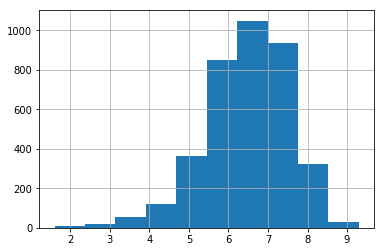

```python
df['imdb_score'].hist()
```

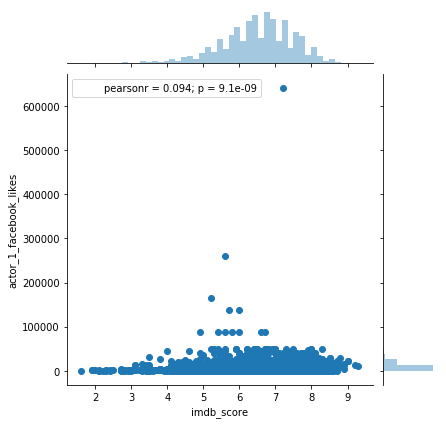

```python
sns.jointplot("imdb_score", "actor_1_facebook_likes", df)
```

## number of likes of main actor does not have a large factor of success

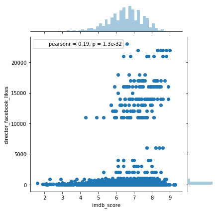

```python
import seaborn as sns
sns.jointplot("imdb_score", "director_facebook_likes", df)
```

### more well know directors almost always have scores over 6. However this is not so say lesser known directors do not produce high rated movies as well. Picking a highly rated director is nearly a guarantee of a good rating.

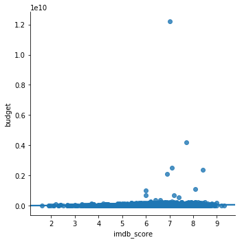

```python
sns.lmplot('imdb_score', 'budget', data= df)
```

## no correlation between budget and rating

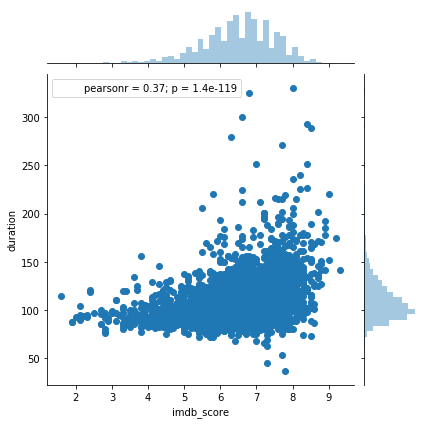

```python
sns.jointplot("imdb_score", "duration", df)
```

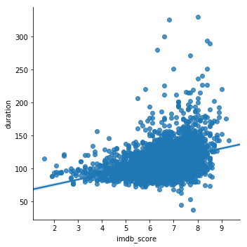

```python
sns.lmplot('imdb_score', 'duration', data= df)
```

## there is a correlation between the lenght of the movie and the rating of the movie. Longer movies tend to be rated higher. All movies over 9 are over 2 hours in lenght

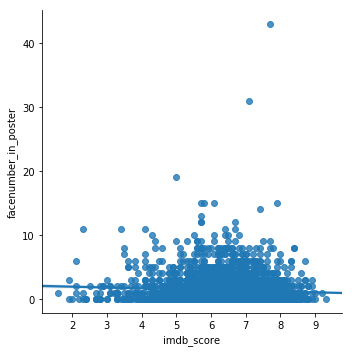

```python
sns.lmplot('imdb_score', 'facenumber_in_poster', data= df)
```

## no correlation between number of faces on posters and success of movie

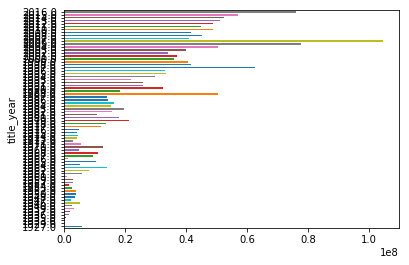

```python
df.groupby('title_year')['budget'].mean().plot(kind='barh')
```

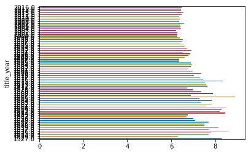

```python
df.groupby('title_year')['imdb_score'].mean().plot(kind='barh')
```

## no correlation between the average budget per year and scores

[figure not shown]

```python
df.groupby('budget')['imdb_score'].mean().plot(kind='barh')
```

## not even a corelation between budget and scores

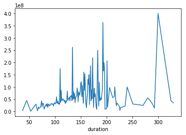

```python
df.groupby('duration')['budget'].mean().plot()
```

# 5. Correlation Analysis

## since we have prepared the data earlier in the project we can just perform a correlation analysis here

```python
df.corr()
```

|  | duration | director_facebook_likes | actor_3_facebook_likes | actor_1_facebook_likes | facenumber_in_poster | num_user_for_reviews | budget | title_year | actor_2_facebook_likes | imdb_score | ... | rating__GP | rating__M | rating__NC-17 | rating__Not Rated | rating__PG | rating__PG-13 | rating__Passed | rating__R | rating__Unrated | rating__X |
| --- | --- | --- | --- | --- | --- | --- | --- | --- | --- | --- | --- | --- | --- | --- | --- | --- | --- | --- | --- | --- | --- |
| duration | 1.000000 | 0.180644 | 0.125797 | 0.083632 | 0.026919 | 0.351595 | 0.068012 | -0.130211 | 0.128935 | 0.366221 | ... | 0.007021 | 0.016047 | -0.012821 | -0.009779 | -0.099026 | 0.063836 | -0.009062 | 0.035703 | -0.005189 | -0.044398 |
| director_facebook_likes | 0.180644 | 1.000000 | 0.117405 | 0.089630 | -0.048067 | 0.217103 | 0.018167 | -0.044656 | 0.116058 | 0.192314 | ... | -0.003858 | -0.005533 | -0.007941 | -0.014840 | 0.000689 | 0.006037 | -0.006897 | 0.013496 | -0.017456 | -0.011766 |
| actor_3_facebook_likes | 0.125797 | 0.117405 | 1.000000 | 0.252408 | 0.106189 | 0.205343 | 0.039966 | 0.117475 | 0.553755 | 0.065544 | ... | -0.005138 | -0.005481 | -0.009383 | -0.030713 | 0.005088 | 0.097472 | -0.009304 | -0.072611 | -0.024989 | -0.014749 |
| actor_1_facebook_likes | 0.083632 | 0.089630 | 0.252408 | 1.000000 | 0.057387 | 0.121935 | 0.016418 | 0.096194 | 0.391166 | 0.093597 | ... | -0.007895 | -0.010457 | -0.006954 | -0.038833 | -0.012277 | 0.056652 | -0.013486 | -0.014850 | -0.035911 | 0.002075 |
| facenumber_in_poster | 0.026919 | -0.048067 | 0.106189 | 0.057387 | 1.000000 | -0.080971 | -0.021673 | 0.070093 | 0.073098 | -0.065493 | ... | 0.004979 | 0.001388 | -0.017191 | -0.003893 | -0.024621 | 0.068317 | 0.031710 | -0.027343 | 0.001197 | 0.000576 |
| num_user_for_reviews | 0.351595 | 0.217103 | 0.205343 | 0.121935 | -0.080971 | 1.000000 | 0.070372 | 0.019470 | 0.187016 | 0.325003 | ... | -0.002415 | 0.002451 | -0.010897 | -0.048764 | -0.092546 | 0.100773 | -0.007255 | 0.000783 | -0.039140 | 0.002244 |
| budget | 0.068012 | 0.018167 | 0.039966 | 0.016418 | -0.021673 | 0.070372 | 1.000000 | 0.047138 | 0.035715 | 0.029190 | ... | -0.002819 | -0.004059 | -0.006555 | -0.017164 | 0.015038 | 0.032978 | -0.005495 | -0.034430 | -0.012659 | -0.009767 |
| title_year | -0.130211 | -0.044656 | 0.117475 | 0.096194 | 0.070093 | 0.019470 | 0.047138 | 1.000000 | 0.122410 | -0.134982 | ... | -0.052780 | -0.079322 | -0.024854 | -0.043560 | -0.054177 | 0.181253 | -0.181999 | -0.018728 | -0.085925 | -0.100737 |
| actor_2_facebook_likes | 0.128935 | 0.116058 | 0.553755 | 0.391166 | 0.073098 | 0.187016 | 0.035715 | 0.122410 | 1.000000 | 0.102372 | ... | -0.006625 | -0.008034 | -0.014073 | -0.035794 | -0.013214 | 0.059675 | -0.011142 | -0.014155 | -0.029923 | -0.019006 |
| imdb_score | 0.366221 | 0.192314 | 0.065544 | 0.093597 | -0.065493 | 0.325003 | 0.029190 | -0.134982 | 0.102372 | 1.000000 | ... | 0.003627 | 0.021521 | -0.003735 | 0.045464 | -0.066697 | -0.134294 | 0.017884 | 0.149977 | 0.034899 | 0.003655 |
| aspect_ratio | 0.153027 | 0.037528 | 0.046356 | 0.056946 | 0.018988 | 0.098109 | 0.025264 | 0.216614 | 0.063951 | 0.029979 | ... | 0.011048 | 0.015626 | -0.019755 | -0.033400 | -0.055263 | 0.087958 | -0.059347 | -0.016749 | 0.079537 | -0.016248 |
| color_ Black and White | 0.048105 | 0.058951 | -0.021618 | -0.025271 | 0.004540 | 0.069949 | -0.015116 | -0.153293 | -0.020536 | 0.117679 | ... | -0.003015 | -0.004265 | 0.029921 | 0.092472 | -0.015352 | -0.041230 | 0.100269 | 0.014599 | 0.024872 | 0.048288 |
| color_Color | -0.048105 | -0.058951 | 0.021618 | 0.025271 | -0.004540 | -0.069949 | 0.015116 | 0.153293 | 0.020536 | -0.117679 | ... | 0.003015 | 0.004265 | -0.029921 | -0.092472 | 0.015352 | 0.041230 | -0.100269 | -0.014599 | -0.024872 | -0.048288 |
| rating__Approved | 0.048979 | -0.015355 | -0.019090 | -0.027375 | -0.004690 | -0.012631 | -0.011992 | -0.307949 | -0.025441 | 0.064186 | ... | -0.001100 | -0.001556 | -0.002697 | -0.006445 | -0.028403 | -0.049288 | -0.001906 | -0.061314 | -0.005176 | -0.003484 |
| rating__G | -0.080780 | -0.031665 | -0.029317 | -0.040077 | -0.065745 | -0.042084 | 0.003345 | -0.081628 | -0.047376 | 0.005397 | ... | -0.002513 | -0.003554 | -0.006160 | -0.014718 | -0.064863 | -0.112560 | -0.004354 | -0.140023 | -0.011820 | -0.007956 |
| rating__GP | 0.007021 | -0.003858 | -0.005138 | -0.007895 | 0.004979 | -0.002415 | -0.002819 | -0.052780 | -0.006625 | 0.003627 | ... | 1.000000 | -0.000377 | -0.000653 | -0.001560 | -0.006874 | -0.011929 | -0.000461 | -0.014839 | -0.001253 | -0.000843 |
| rating__M | 0.016047 | -0.005533 | -0.005481 | -0.010457 | 0.001388 | 0.002451 | -0.004059 | -0.079322 | -0.008034 | 0.021521 | ... | -0.000377 | 1.000000 | -0.000923 | -0.002206 | -0.009723 | -0.016872 | -0.000653 | -0.020988 | -0.001772 | -0.001193 |
| rating__NC-17 | -0.012821 | -0.007941 | -0.009383 | -0.006954 | -0.017191 | -0.010897 | -0.006555 | -0.024854 | -0.014073 | -0.003735 | ... | -0.000653 | -0.000923 | 1.000000 | -0.003823 | -0.016849 | -0.029239 | -0.001131 | -0.036372 | -0.003070 | -0.002067 |
| rating__Not Rated | -0.009779 | -0.014840 | -0.030713 | -0.038833 | -0.003893 | -0.048764 | -0.017164 | -0.043560 | -0.035794 | 0.045464 | ... | -0.001560 | -0.002206 | -0.003823 | 1.000000 | -0.040259 | -0.069863 | -0.002702 | -0.086909 | -0.007336 | -0.004938 |
| rating__PG | -0.099026 | 0.000689 | 0.005088 | -0.012277 | -0.024621 | -0.092546 | 0.015038 | -0.054177 | -0.013214 | -0.066697 | ... | -0.006874 | -0.009723 | -0.016849 | -0.040259 | 1.000000 | -0.307901 | -0.011909 | -0.383024 | -0.032332 | -0.021764 |
| rating__PG-13 | 0.063836 | 0.006037 | 0.097472 | 0.056652 | 0.068317 | 0.100773 | 0.032978 | 0.181253 | 0.059675 | -0.134294 | ... | -0.011929 | -0.016872 | -0.029239 | -0.069863 | -0.307901 | 1.000000 | -0.020667 | -0.664678 | -0.056108 | -0.037767 |
| rating__Passed | -0.009062 | -0.006897 | -0.009304 | -0.013486 | 0.031710 | -0.007255 | -0.005495 | -0.181999 | -0.011142 | 0.017884 | ... | -0.000461 | -0.000653 | -0.001131 | -0.002702 | -0.011909 | -0.020667 | 1.000000 | -0.025709 | -0.002170 | -0.001461 |
| rating__R | 0.035703 | 0.013496 | -0.072611 | -0.014850 | -0.027343 | 0.000783 | -0.034430 | -0.018728 | -0.014155 | 0.149977 | ... | -0.014839 | -0.020988 | -0.036372 | -0.086909 | -0.383024 | -0.664678 | -0.025709 | 1.000000 | -0.069797 | -0.046982 |
| rating__Unrated | -0.005189 | -0.017456 | -0.024989 | -0.035911 | 0.001197 | -0.039140 | -0.012659 | -0.085925 | -0.029923 | 0.034899 | ... | -0.001253 | -0.001772 | -0.003070 | -0.007336 | -0.032332 | -0.056108 | -0.002170 | -0.069797 | 1.000000 | -0.003966 |
| rating__X | -0.044398 | -0.011766 | -0.014749 | 0.002075 | 0.000576 | 0.002244 | -0.009767 | -0.100737 | -0.019006 | 0.003655 | ... | -0.000843 | -0.001193 | -0.002067 | -0.004938 | -0.021764 | -0.037767 | -0.001461 | -0.046982 | -0.003966 | 1.000000 |

25 rows × 25 columns

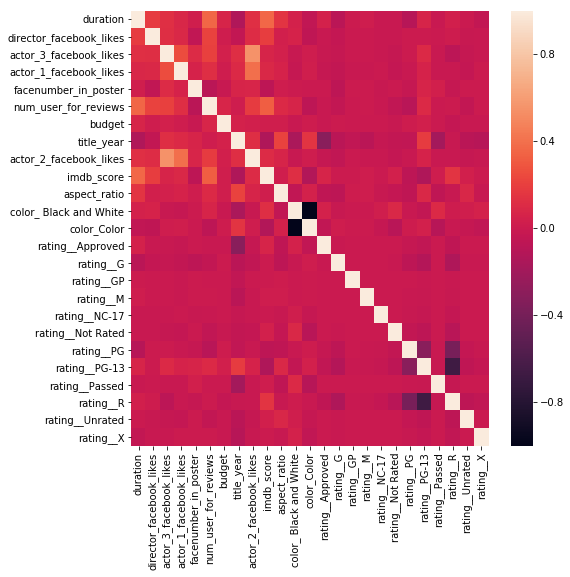

```python
plt.figure(figsize=(8, 8))
sns.heatmap(df.corr())
```

## findings from correlation analysis

## - Rated R movies tended to have higher correlations with imdb_scores of all the ratings

# 6. Story Telling

## - the longer the movie the higher average imdb_score the movie received.

## - In my opinion, the reason for this is that directors have more time to develop deeper plot lines, build suspense, and create more dynamic characters. These factors often influence the impact of movies on the viewer.